# LinearatauSequential

**Linear Search dan Sequential Search** adalah dua istilah berbeda yang merujuk pada algoritma pencarian yang sama persis.

Kenapa Punya Dua Nama?

**Linear (Garis Lurus)**: Mengacu pada jalurnya. Algoritma ini berjalan lurus dari indeks awal hingga akhir tanpa melompat-lompat.

**Sequential (Berurutan)**: Mengacu pada prosesnya. Algoritma ini mengecek elemen satu per satu secara berurutan sesuai urutannya di dalam array atau list.

# Linear Search

## Introduction to Searching (Pencarian)

Linear Search Pencarian adalah proses mendasar untuk menemukan elemen atau item tertentu dalam kumpulan data. Kumpulan data ini dapat berupa berbagai bentuk, seperti array, daftar, pohon, atau representasi terstruktur lainnya.

Basic Searching Algorithms: Linear Search – O(n) Time and O(1) Space

Ini adalah algoritma pencarian paling sederhana yang memeriksa setiap elemen secara berurutan hingga kunci ditemukan atau seluruh koleksi telah dijelajahi. Bekerja pada data yang sudah diurutkan maupun yang belum diurutkan.

### Pencarian Linier

Algoritma Pencarian Linier mencari melalui sebuah array dan mengembalikan indeks dari nilai yang dicari.

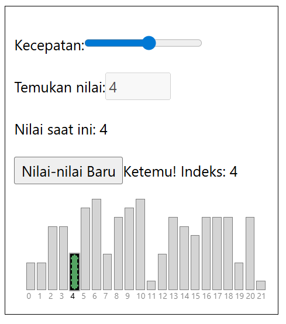

alankan simulasi di atas untuk melihat cara kerja algoritma Pencarian Linier.

Untuk melihat apa yang terjadi ketika suatu nilai tidak ditemukan, coba cari nilai 5.

Algoritma ini sangat sederhana dan mudah dipahami serta diimplementasikan.

Jika array sudah diurutkan, lebih baik menggunakan algoritma Pencarian Biner yang jauh lebih cepat yang akan kita bahas di halaman berikutnya.

Perbedaan besar antara algoritma pengurutan dan algoritma pencarian adalah bahwa algoritma pengurutan memodifikasi array, sedangkan algoritma pencarian membiarkan array tidak berubah.

### Cara kerjanya:

1. Telusuri array nilai demi nilai dari awal.
2. Bandingkan setiap nilai untuk memeriksa apakah nilainya sama dengan nilai yang kita cari.
3. Jika nilai tersebut ditemukan, kembalikan indeks dari nilai tersebut.
4. Jika akhir array tercapai dan nilai tidak ditemukan, kembalikan -1 untuk menunjukkan bahwa nilai tersebut tidak ditemukan.

### Implementasi Pencarian Linier

Untuk mengimplementasikan algoritma Pencarian Linier, kita membutuhkan:

1. Sebuah array berisi nilai-nilai yang akan dicari.
2. Nilai target yang akan dicari.
3. Sebuah perulangan yang menelusuri array dari awal hingga akhir.
4. Sebuah pernyataan if yang membandingkan nilai saat ini dengan nilai target, dan mengembalikan indeks saat ini jika nilai target ditemukan.
5. Setelah perulangan, kembalikan -1, karena pada titik ini kita tahu nilai target belum ditemukan. Kode yang dihasilkan untuk Pencarian Linier akan terlihat seperti ini:

```python
def linearSearch(arr, targetVal):
    for i in range(len(arr)):
        if arr[i] == targetVal:
            return i
    return -1

arr = [3, 7, 2, 9, 5]
targetVal = 9

result = linearSearch(arr, targetVal)

if result != -1:
    print("Value",targetVal,"found at index",result)
else:
    print("Value",targetVal,"not found")
```

```
Value 9 found at index 3
```

# Sequential Searching

Pencarian data terkadang sangat diperlukan pada proses komputasi, sistem informasi, dan lain- lain. Dengan pencarian data ini maka data yang diperlukan dapat diketahui posisinya terhadap

kumpulan data yang lain, sehingga data ini dapat digunakan untuk proses berikutnya. Misalkan pada data mahasiswa, diperlukan data lengkap tentang mahasiswa dengan Nomor induk XXXXXX, maka diperlukan proses pencarian data tersebut dengan key berupa nomor induk mahasiswa. Data yang didapat ini dapat digunakan untuk keperluan yang lain, misalkan keperluan administratif.

Pada umumnya, proses pencarian data ini menghasilkan posisi data yang dicari terhadap keseluruhan data, akan tetapi untuk pencarian data yang sederhana, nilai True atau False saja yang dihasilkan, nilai ini menandakan apakah data berada di sekumpulan data ataukah tidak.

**Sequential Search** merupakan teknik pencarian data dengan cara membandingkan data yang dicari dengan seluruh data yang terdapat pada kumpulan data secara satu persatu, mulai dari data pertama sampai dengan data terakhir. Ilustrasi sequential search ini dapat dilihat pada Gambar 1 berikut.

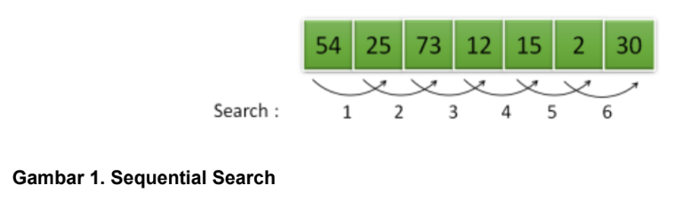

Terdapat dua konsep untuk sequential search berdasarkan kumpulan data yang akan dicari, yaitu

1. Unordered List Sequential Search
2. Ordered List Sequential Search

### Unordered List Sequential Search

Pada unordered list sequential search, data berada pada keadaan acak, tidak terurut, sehingga pencarian harus dilakukan mulai dari indeks awal sampai indeks terakhir dari data, atau pencarian berhenti ketika data sudah ditemukan

Berikut implementasi algoritma unordered list sequential search.

```python
def seqSearch(listData, data):
    ind = 0
    found = False
    while ind < len(listData) and not found:
        if listData[ind] == data:
            found = True
        else:
            ind = ind+1
    return found

a=[12,5,9,8,1,10,26]
seqSearch(a,1)
```

```
True
```

### Ordered List Sequential Search

Pada ordered list sequential search, data sudah dalam keadaan terurut, hal ini tentunya dapat mengurangi waktu komputasi pencarian. Ilustrasi algoritma pencarian ini, dapat dilihat pada Gambar 2 berikut:

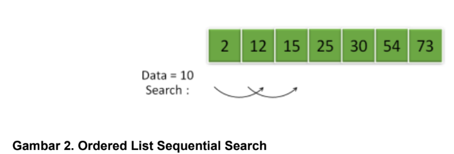

Berikut implementasi algoritma sequential search pada ordered list

```python
def orderedSeqSearch(listData, data):
    ind = 0
    found = False
    stop = False
    position=[]
    while ind < len(listData) and not found and not stop:
        if listData[ind] == data:
            found = True
            position.append(ind)
        else:
            if listData[ind] > data:
                stop = True
            else:
                ind = ind+1
    if found:
        return ind
    else:
        return ('Data tidak ada')

a=[1,1,5,5,5,8,9,10,12,26]

ind=orderedSeqSearch(a,5)
print(ind)
```

```
2
```

### Soal-Soal

1. Mengembalikan Index atau 'Data tidak ada'

```python
def seqSearch_mod1(listData, data):
    ind = 0
    found = False
    while ind < len(listData) and not found:
        if listData[ind] == data:
            found = True
        else:
            ind = ind + 1
    if found:
        return ind
    else:
        return 'Data tidak ada'

a = [12, 5, 9, 8, 1, 10, 26]
print(seqSearch_mod1(a, 1))
print(seqSearch_mod1(a, 99))
```

```
4
Data tidak ada
```

2. Mencari Semua Data (Menangani Duplikat)

```python
def seqSearch_mod2(listData, data):
    ind = 0
    hasil_index = []
    while ind < len(listData):
        if listData[ind] == data:
            hasil_index.append(ind)
        ind = ind + 1
    if len(hasil_index) > 0:
        return hasil_index
    else:
        return 'Data tidak ada'

b = [12, 5, 1, 8, 1, 10, 1]
print(seqSearch_mod2(b, 1))   # Output: [2, 4, 6]
print(seqSearch_mod2(b, 99))  # Output: Data tidak ada
```

```
[2, 4, 6]
Data tidak ada
```